# Курсова работа по "Интелигентни системи"

## Изготвили

### 118010 - Ради Атанасов

### 118326 - Петър Нешков

```python
import pandas as pd
import numpy as np
import matplotlib.pyplot as plt
import seaborn as sns
%matplotlib inline
import os
```

## Описание на данните

```python
data=pd.read_csv(os.getcwd()+'\\Cancer_Data.csv')
```

```python
data.head()
```

|  | id | diagnosis | radius_mean | texture_mean | perimeter_mean | area_mean | smoothness_mean | compactness_mean | concavity_mean | concave points_mean | ... | texture_worst | perimeter_worst | area_worst | smoothness_worst | compactness_worst | concavity_worst | concave points_worst | symmetry_worst | fractal_dimension_worst | Unnamed: 32 |
| --- | --- | --- | --- | --- | --- | --- | --- | --- | --- | --- | --- | --- | --- | --- | --- | --- | --- | --- | --- | --- | --- |
| 0 | 842302 | M | 17.99 | 10.38 | 122.80 | 1001.0 | 0.11840 | 0.27760 | 0.3001 | 0.14710 | ... | 17.33 | 184.60 | 2019.0 | 0.1622 | 0.6656 | 0.7119 | 0.2654 | 0.4601 | 0.11890 | NaN |
| 1 | 842517 | M | 20.57 | 17.77 | 132.90 | 1326.0 | 0.08474 | 0.07864 | 0.0869 | 0.07017 | ... | 23.41 | 158.80 | 1956.0 | 0.1238 | 0.1866 | 0.2416 | 0.1860 | 0.2750 | 0.08902 | NaN |
| 2 | 84300903 | M | 19.69 | 21.25 | 130.00 | 1203.0 | 0.10960 | 0.15990 | 0.1974 | 0.12790 | ... | 25.53 | 152.50 | 1709.0 | 0.1444 | 0.4245 | 0.4504 | 0.2430 | 0.3613 | 0.08758 | NaN |
| 3 | 84348301 | M | 11.42 | 20.38 | 77.58 | 386.1 | 0.14250 | 0.28390 | 0.2414 | 0.10520 | ... | 26.50 | 98.87 | 567.7 | 0.2098 | 0.8663 | 0.6869 | 0.2575 | 0.6638 | 0.17300 | NaN |
| 4 | 84358402 | M | 20.29 | 14.34 | 135.10 | 1297.0 | 0.10030 | 0.13280 | 0.1980 | 0.10430 | ... | 16.67 | 152.20 | 1575.0 | 0.1374 | 0.2050 | 0.4000 | 0.1625 | 0.2364 | 0.07678 | NaN |

5 rows × 33 columns

```python
print(data.columns)
```

```
Index(['id', 'diagnosis', 'radius_mean', 'texture_mean', 'perimeter_mean',
       'area_mean', 'smoothness_mean', 'compactness_mean', 'concavity_mean',
       'concave points_mean', 'symmetry_mean', 'fractal_dimension_mean',
       'radius_se', 'texture_se', 'perimeter_se', 'area_se', 'smoothness_se',
       'compactness_se', 'concavity_se', 'concave points_se', 'symmetry_se',
       'fractal_dimension_se', 'radius_worst', 'texture_worst',
       'perimeter_worst', 'area_worst', 'smoothness_worst',
       'compactness_worst', 'concavity_worst', 'concave points_worst',
       'symmetry_worst', 'fractal_dimension_worst', 'Unnamed: 32'],
      dtype='object')
```

- id - уникален идентификатор за всеки пациент в базата данни
- diagnosis - дали раковата клетка е доброкачествена (B) или злокачествена (M)
- radius_mean - среден радиус на клетката
- texture_mean - средна текстура на клетката
- perimeter_mean - среден периметър на клетката
- area_mean - средна площ на клетката
- smoothness_mean - средна гладкост на клетката
- compactness_mean - средна компактност на клетката
- concavity_mean - средна вдлъбнатост на клетката
- concave points_mean - средния брой на вдлъбнатите точки на клетката
- symmetry_mean - средна симетрия на клетката
- fractal_dimension_mean - средна фрактална размерност на клетката
- radius_se - стандартното отклонение на радиуса на клетката
- texture_se - стандартното отклонение на текстурата на клетката
- perimeter_se - стандартното отклонение на периметъра на клетката
- area_se - стандартното отклонение на площта на клетката
- smoothness_se - стандартното отклонение на гладкостта на клетката
- compactness_se - стандартното отклонение на компактността на клетката
- concavity_se - стандартното отклонение на вдлъбнатостта на клетката
- concave points_se - стандартното отклонение на броя вдлъбнати точки на клетката
- symmetry_se - стандартното отклонение на симетрията на клетката
- fractal_dimension_se - стандартното отклонение на фракталната размерност на клетката
- radius_worst - най-голямото измерение на радиуса на клетката
- texture_worst - най-голямото измерение на текстурата на клетката
- perimeter_worst - най-голямото измерение на периметъра на клетката
- area_worst - най-голямото измерение на площта на клетката
- smoothness_worst - най-голямата гладкост на клетката
- compactness_worst - най-голямата компактност на клетката
- concavity_worst - най-голямата вдлъбнатост на клетката
- concave points_worst - точки с най-голямата вдлъбнатост
- symmetry_worst - степента на симетрия на раковата клетка
- fractal_dimension_worst - Фракталната размерност на клетката

#### Структура на набора от данни

```python
data.info()
```

```
<class 'pandas.core.frame.DataFrame'>
RangeIndex: 569 entries, 0 to 568
Data columns (total 33 columns):
 #   Column                   Non-Null Count  Dtype
---  ------                   --------------  -----
 0   id                       569 non-null    int64
 1   diagnosis                569 non-null    object
 2   radius_mean              569 non-null    float64
 3   texture_mean             569 non-null    float64
 4   perimeter_mean           569 non-null    float64
 5   area_mean                569 non-null    float64
 6   smoothness_mean          569 non-null    float64
 7   compactness_mean         569 non-null    float64
 8   concavity_mean           569 non-null    float64
 9   concave points_mean      569 non-null    float64
```

[output cut: 25 more lines]

#### Описателна статистика за числовите колони

```python
data.describe()
```

|  | id | radius_mean | texture_mean | perimeter_mean | area_mean | smoothness_mean | compactness_mean | concavity_mean | concave points_mean | symmetry_mean | ... | texture_worst | perimeter_worst | area_worst | smoothness_worst | compactness_worst | concavity_worst | concave points_worst | symmetry_worst | fractal_dimension_worst | Unnamed: 32 |
| --- | --- | --- | --- | --- | --- | --- | --- | --- | --- | --- | --- | --- | --- | --- | --- | --- | --- | --- | --- | --- | --- |
| count | 5.690000e+02 | 569.000000 | 569.000000 | 569.000000 | 569.000000 | 569.000000 | 569.000000 | 569.000000 | 569.000000 | 569.000000 | ... | 569.000000 | 569.000000 | 569.000000 | 569.000000 | 569.000000 | 569.000000 | 569.000000 | 569.000000 | 569.000000 | 0.0 |
| mean | 3.037183e+07 | 14.127292 | 19.289649 | 91.969033 | 654.889104 | 0.096360 | 0.104341 | 0.088799 | 0.048919 | 0.181162 | ... | 25.677223 | 107.261213 | 880.583128 | 0.132369 | 0.254265 | 0.272188 | 0.114606 | 0.290076 | 0.083946 | NaN |
| std | 1.250206e+08 | 3.524049 | 4.301036 | 24.298981 | 351.914129 | 0.014064 | 0.052813 | 0.079720 | 0.038803 | 0.027414 | ... | 6.146258 | 33.602542 | 569.356993 | 0.022832 | 0.157336 | 0.208624 | 0.065732 | 0.061867 | 0.018061 | NaN |
| min | 8.670000e+03 | 6.981000 | 9.710000 | 43.790000 | 143.500000 | 0.052630 | 0.019380 | 0.000000 | 0.000000 | 0.106000 | ... | 12.020000 | 50.410000 | 185.200000 | 0.071170 | 0.027290 | 0.000000 | 0.000000 | 0.156500 | 0.055040 | NaN |
| 25% | 8.692180e+05 | 11.700000 | 16.170000 | 75.170000 | 420.300000 | 0.086370 | 0.064920 | 0.029560 | 0.020310 | 0.161900 | ... | 21.080000 | 84.110000 | 515.300000 | 0.116600 | 0.147200 | 0.114500 | 0.064930 | 0.250400 | 0.071460 | NaN |
| 50% | 9.060240e+05 | 13.370000 | 18.840000 | 86.240000 | 551.100000 | 0.095870 | 0.092630 | 0.061540 | 0.033500 | 0.179200 | ... | 25.410000 | 97.660000 | 686.500000 | 0.131300 | 0.211900 | 0.226700 | 0.099930 | 0.282200 | 0.080040 | NaN |
| 75% | 8.813129e+06 | 15.780000 | 21.800000 | 104.100000 | 782.700000 | 0.105300 | 0.130400 | 0.130700 | 0.074000 | 0.195700 | ... | 29.720000 | 125.400000 | 1084.000000 | 0.146000 | 0.339100 | 0.382900 | 0.161400 | 0.317900 | 0.092080 | NaN |
| max | 9.113205e+08 | 28.110000 | 39.280000 | 188.500000 | 2501.000000 | 0.163400 | 0.345400 | 0.426800 | 0.201200 | 0.304000 | ... | 49.540000 | 251.200000 | 4254.000000 | 0.222600 | 1.058000 | 1.252000 | 0.291000 | 0.663800 | 0.207500 | NaN |

8 rows × 32 columns

#### Описателна статистика за текстовите колони

```python
data.describe(include='object')
```

|  | diagnosis |
| --- | --- |
| count | 569 |
| unique | 2 |
| top | B |
| freq | 357 |

# Липсващи стойности

```python
check_na = pd.DataFrame({'Missing values count': pd.isnull(data).sum(),
                         'Missing values %': pd.isnull(data).sum() / data.shape[0]}).style.format({'Missing values %': '{:.2%}'})
```

```python
check_na
```

|  | Missing values count | Missing values % |
| --- | --- | --- |
| id | 0 | 0.00% |
| diagnosis | 0 | 0.00% |
| radius_mean | 0 | 0.00% |
| texture_mean | 0 | 0.00% |
| perimeter_mean | 0 | 0.00% |
| area_mean | 0 | 0.00% |
| smoothness_mean | 0 | 0.00% |
| compactness_mean | 0 | 0.00% |
| concavity_mean | 0 | 0.00% |
| concave points_mean | 0 | 0.00% |
| symmetry_mean | 0 | 0.00% |
| fractal_dimension_mean | 0 | 0.00% |
| radius_se | 0 | 0.00% |
| texture_se | 0 | 0.00% |
| perimeter_se | 0 | 0.00% |
| area_se | 0 | 0.00% |
| smoothness_se | 0 | 0.00% |
| compactness_se | 0 | 0.00% |
| concavity_se | 0 | 0.00% |
| concave points_se | 0 | 0.00% |
| symmetry_se | 0 | 0.00% |
| fractal_dimension_se | 0 | 0.00% |
| radius_worst | 0 | 0.00% |
| texture_worst | 0 | 0.00% |
| perimeter_worst | 0 | 0.00% |
| area_worst | 0 | 0.00% |
| smoothness_worst | 0 | 0.00% |
| compactness_worst | 0 | 0.00% |
| concavity_worst | 0 | 0.00% |
| concave points_worst | 0 | 0.00% |
| symmetry_worst | 0 | 0.00% |
| fractal_dimension_worst | 0 | 0.00% |
| Unnamed: 32 | 569 | 100.00% |

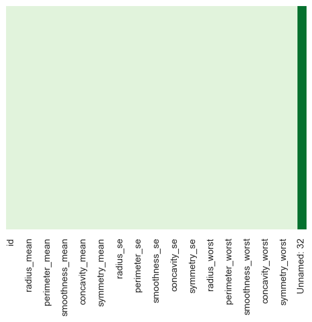

```python
sns.heatmap(data.isnull(),yticklabels=False, cbar=False,cmap=sns.color_palette('Greens'))
```

```python
data['Unnamed: 32']
```

```
0     NaN
1     NaN
2     NaN
3     NaN
4     NaN
       ..
564   NaN
565   NaN
566   NaN
567   NaN
568   NaN
Name: Unnamed: 32, Length: 569, dtype: float64
```

```python
data.drop(columns='Unnamed: 32', inplace=True)
```

```python
pd.DataFrame(data.columns)
```

|  | 0 |
| --- | --- |
| 0 | id |
| 1 | diagnosis |
| 2 | radius_mean |
| 3 | texture_mean |
| 4 | perimeter_mean |
| 5 | area_mean |
| 6 | smoothness_mean |
| 7 | compactness_mean |
| 8 | concavity_mean |
| 9 | concave points_mean |
| 10 | symmetry_mean |
| 11 | fractal_dimension_mean |
| 12 | radius_se |
| 13 | texture_se |
| 14 | perimeter_se |
| 15 | area_se |
| 16 | smoothness_se |
| 17 | compactness_se |
| 18 | concavity_se |
| 19 | concave points_se |
| 20 | symmetry_se |
| 21 | fractal_dimension_se |
| 22 | radius_worst |
| 23 | texture_worst |
| 24 | perimeter_worst |
| 25 | area_worst |
| 26 | smoothness_worst |
| 27 | compactness_worst |
| 28 | concavity_worst |
| 29 | concave points_worst |
| 30 | symmetry_worst |
| 31 | fractal_dimension_worst |

# Предварителен анализ на данните

```python
sns.set_theme(style='darkgrid', palette='deep')
```

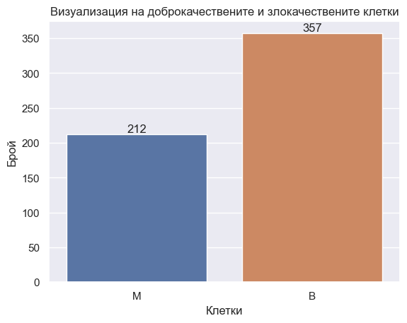

```python
g=sns.countplot(data=data, x='diagnosis')
for i in g.containers:
 plt.bar_label(i)
g.set(title='Визуализация на доброкачествените и злокачествените клетки')
plt.xlabel('Клетки')
plt.ylabel('Брой')
plt.show()
```

#### Проверка на корелация между променливите

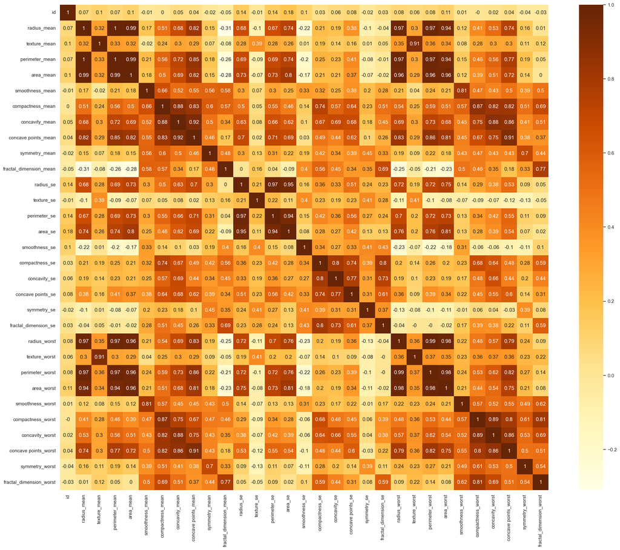

```python
corr = data.corr().round(2)
plt.figure(figsize = (25,20))
sns.heatmap(corr, annot = True, cmap = 'YlOrBr')
```

### Изобразяване на нашите непрекъснати променливи и проверка дали нашите данни вече са нормализирани

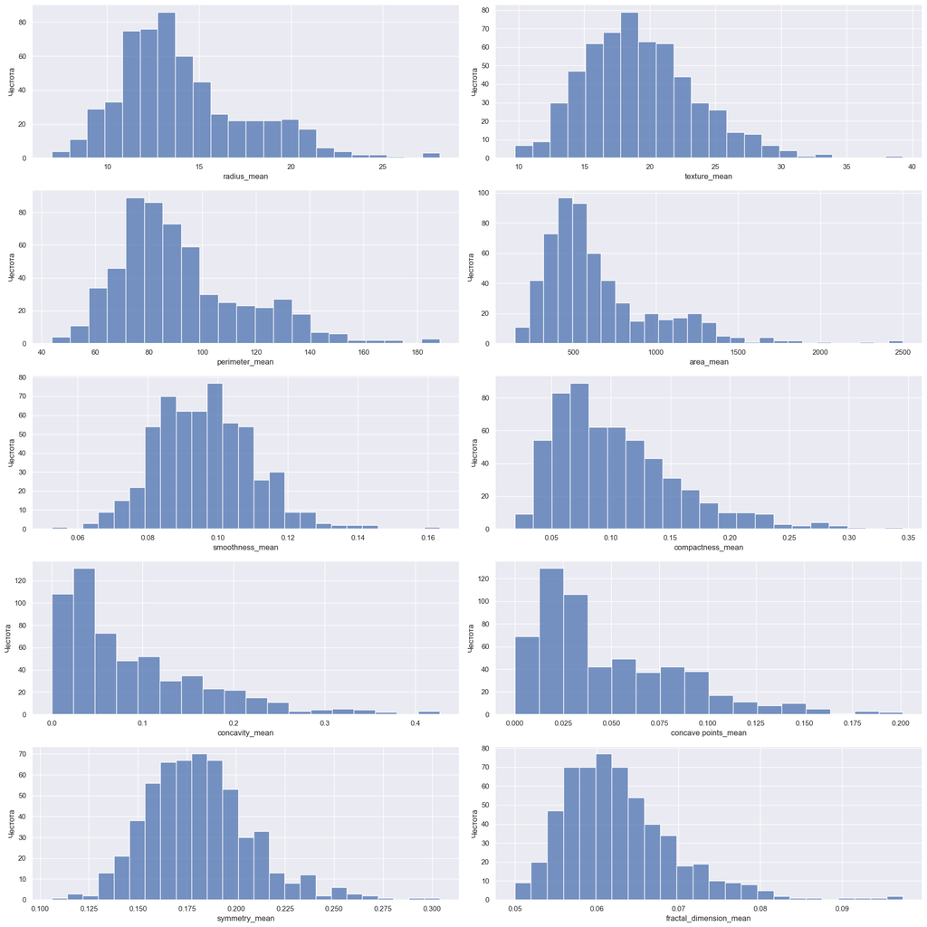

```python
plt.figure(figsize=(20,20))

for i in range(10):
    plt.subplot(5,2,i+1)
    sns.histplot(x=data[data.columns[i+2]], kde=False)
    plt.xlabel(data.columns[i+2])
    plt.ylabel('Честота')

plt.tight_layout()
plt.show()
```

В анализа на нашите променливи могат да обяснят резултата добре, можем да видим, че в повечето от променливите, колкото по-високи са стойностите, толкова по-голям е шансът резултатът **Рак** да е злокачествен.

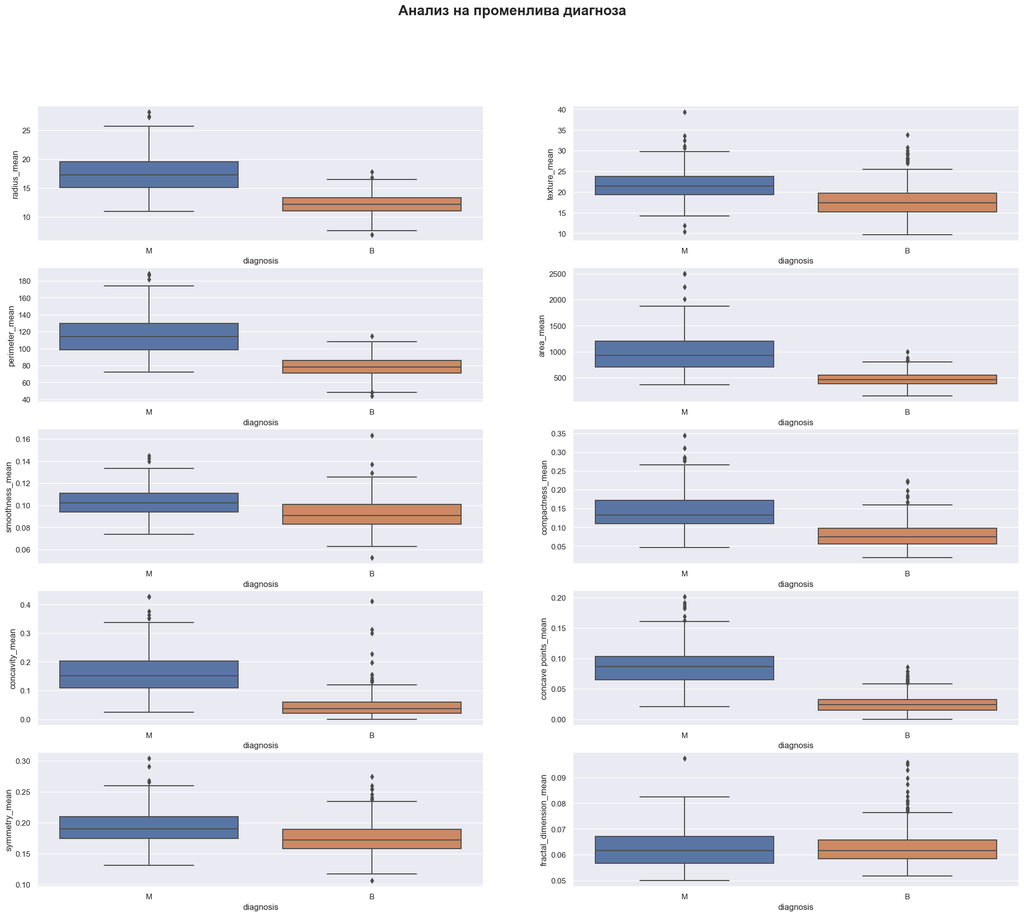

```python
plt.figure(figsize = (25, 20))
plt.suptitle("Анализ на променлива диагноза",fontweight="bold", fontsize=20)

plt.subplot(5,2,1)
sns.boxplot(x="diagnosis", y="radius_mean", data=data)

plt.subplot(5,2,2)
sns.boxplot(x="diagnosis", y="texture_mean", data=data)

plt.subplot(5,2,3)
sns.boxplot(x="diagnosis", y="perimeter_mean", data=data)

plt.subplot(5,2,4)
sns.boxplot(x="diagnosis", y="area_mean", data=data)

plt.subplot(5,2,5)
sns.boxplot(x="diagnosis", y="smoothness_mean", data=data)

plt.subplot(5,2,6)
sns.boxplot(x="diagnosis", y="compactness_mean", data=data)

plt.subplot(5,2,7)
sns.boxplot(x="diagnosis", y="concavity_mean", data=data)

plt.subplot(5,2,8)
sns.boxplot(x="diagnosis", y="concave points_mean", data=data)

plt.subplot(5,2,9)
sns.boxplot(x="diagnosis", y="symmetry_mean", data=data)

plt.subplot(5,2,10)
sns.boxplot(x="diagnosis", y="fractal_dimension_mean", data=data)
```

# Подготовка на данните за обучение на моделите

#### За подготовката на данните от базата данни Cancer_Data ще трябва да се извършат следните стъпки:

Премахване на колоната **diagnosis**: Тази колона съдържа целевата променлива, която ще използваме за обучение на модела, затова трябва да я отделим в отделна променлива. Можем да я отделим като я запазим в нова променлива и я премахнем от оригиналния **DataFrame**:

```python
X = data.drop(columns="diagnosis")
y = data["diagnosis"]
```

```python
X.head()
```

|  | id | radius_mean | texture_mean | perimeter_mean | area_mean | smoothness_mean | compactness_mean | concavity_mean | concave points_mean | symmetry_mean | ... | radius_worst | texture_worst | perimeter_worst | area_worst | smoothness_worst | compactness_worst | concavity_worst | concave points_worst | symmetry_worst | fractal_dimension_worst |
| --- | --- | --- | --- | --- | --- | --- | --- | --- | --- | --- | --- | --- | --- | --- | --- | --- | --- | --- | --- | --- | --- |
| 0 | 842302 | 17.99 | 10.38 | 122.80 | 1001.0 | 0.11840 | 0.27760 | 0.3001 | 0.14710 | 0.2419 | ... | 25.38 | 17.33 | 184.60 | 2019.0 | 0.1622 | 0.6656 | 0.7119 | 0.2654 | 0.4601 | 0.11890 |
| 1 | 842517 | 20.57 | 17.77 | 132.90 | 1326.0 | 0.08474 | 0.07864 | 0.0869 | 0.07017 | 0.1812 | ... | 24.99 | 23.41 | 158.80 | 1956.0 | 0.1238 | 0.1866 | 0.2416 | 0.1860 | 0.2750 | 0.08902 |
| 2 | 84300903 | 19.69 | 21.25 | 130.00 | 1203.0 | 0.10960 | 0.15990 | 0.1974 | 0.12790 | 0.2069 | ... | 23.57 | 25.53 | 152.50 | 1709.0 | 0.1444 | 0.4245 | 0.4504 | 0.2430 | 0.3613 | 0.08758 |
| 3 | 84348301 | 11.42 | 20.38 | 77.58 | 386.1 | 0.14250 | 0.28390 | 0.2414 | 0.10520 | 0.2597 | ... | 14.91 | 26.50 | 98.87 | 567.7 | 0.2098 | 0.8663 | 0.6869 | 0.2575 | 0.6638 | 0.17300 |
| 4 | 84358402 | 20.29 | 14.34 | 135.10 | 1297.0 | 0.10030 | 0.13280 | 0.1980 | 0.10430 | 0.1809 | ... | 22.54 | 16.67 | 152.20 | 1575.0 | 0.1374 | 0.2050 | 0.4000 | 0.1625 | 0.2364 | 0.07678 |

5 rows × 31 columns

```python
pd.DataFrame(y)
```

|  | diagnosis |
| --- | --- |
| 0 | M |
| 1 | M |
| 2 | M |
| 3 | M |
| 4 | M |
| ... | ... |
| 564 | M |
| 565 | M |
| 566 | M |
| 567 | M |
| 568 | B |

569 rows × 1 columns

#### Преобразуване на категорийните данни в числови: Ако има категорийни данни в базата данни, ще трябва да ги преобразуваме в числови за да можем да ги използваме за обучение на модела.

```python
y = y.replace({"M": 1, "B": 0})
y
```

```
0      1
1      1
2      1
3      1
4      1
      ..
564    1
565    1
566    1
567    1
568    0
Name: diagnosis, Length: 569, dtype: int64
```

#### Разделяме набора на обучително и тестово множество в съотношение 80:20

```python
from sklearn.model_selection import train_test_split
```

```python
X_train, X_test, y_train, y_test = train_test_split(X, y, test_size=0.2, random_state=3)
```

Класът **StandardScaler** от библиотеката **sklearn.preprocessing** се използва за стандартизиране (нормализиране) данните в **X_train** и **X_test**. Стандартизацията е необходима, за да се гарантира, че всички характеристики имат еднакъв мащаб.

```python
from sklearn.preprocessing import StandardScaler
sc = StandardScaler()
X_train = sc.fit_transform(X_train)
X_test = sc.fit_transform(X_test)
```

```python
pd.DataFrame(X_train)
```

|  | 0 | 1 | 2 | 3 | 4 | 5 | 6 | 7 | 8 | 9 | ... | 21 | 22 | 23 | 24 | 25 | 26 | 27 | 28 | 29 | 30 |
| --- | --- | --- | --- | --- | --- | --- | --- | --- | --- | --- | --- | --- | --- | --- | --- | --- | --- | --- | --- | --- | --- |
| 0 | -0.174470 | 1.403811 | 1.792834 | 1.379601 | 1.342225 | 0.330349 | 0.705630 | 1.229423 | 1.176285 | 0.260292 | ... | 1.496821 | 1.733735 | 1.512809 | 1.421610 | 1.965576 | 0.765781 | 1.399530 | 1.044121 | 0.522960 | 0.649908 |
| 1 | -0.241765 | 1.165655 | -0.144612 | 1.071214 | 1.071068 | -0.820808 | -0.412695 | -0.119237 | 0.202709 | -0.726151 | ... | 1.008308 | 0.140997 | 0.913198 | 0.886000 | -0.469582 | -0.105030 | 0.349682 | 0.594078 | 0.441538 | -0.852815 |
| 2 | -0.241472 | -0.030728 | -0.772711 | -0.098222 | -0.130408 | -0.913644 | -0.887366 | -0.685403 | -0.523048 | -0.399677 | ... | -0.136960 | -0.657041 | -0.192879 | -0.239804 | -0.642887 | -0.849211 | -0.797285 | -0.640476 | -0.311617 | -0.692928 |
| 3 | -0.241586 | 0.591279 | 0.652592 | 0.620807 | 0.472287 | 1.365820 | 0.392012 | 1.080400 | 0.750693 | 0.144446 | ... | 0.282634 | -0.051000 | 0.170962 | 0.144334 | 0.383612 | -0.310257 | 0.257773 | -0.189386 | -0.294393 | -0.304554 |
| 4 | -0.241733 | 0.949914 | 0.034155 | 0.929193 | 0.821157 | -0.549444 | 0.235203 | 0.148394 | 0.626025 | -1.129855 | ... | 0.827903 | 0.054181 | 0.921931 | 0.594315 | 0.183645 | 0.503165 | 0.335470 | 1.144297 | 0.006243 | -0.351007 |
| ... | ... | ... | ... | ... | ... | ... | ... | ... | ... | ... | ... | ... | ... | ... | ... | ... | ... | ... | ... | ... | ... |
| 450 | -0.241447 | -0.557472 | -0.277479 | -0.564454 | -0.566216 | -0.464464 | -0.528919 | -0.760891 | -0.881374 | -1.277295 | ... | -0.607229 | 0.393097 | -0.552936 | -0.585392 | -0.585119 | -0.208579 | -0.558985 | -0.904072 | -0.811110 | -0.425549 |
| 451 | -0.241494 | -0.711573 | -0.763048 | -0.679288 | -0.697881 | 0.815949 | 0.179858 | -0.250182 | -0.130330 | 0.204124 | ... | -0.749121 | -0.975923 | -0.753777 | -0.707695 | 0.334731 | -0.276572 | -0.235882 | -0.102667 | -0.214537 | -0.588677 |
| 452 | -0.241841 | 1.064789 | 0.200843 | 0.892674 | 0.906138 | -0.953634 | -0.734800 | -0.226240 | 0.147582 | 1.057169 | ... | 0.860335 | 0.386419 | 0.622125 | 0.631842 | -1.189464 | -0.880400 | -0.260992 | 0.016946 | 3.065836 | -1.299527 |
| 453 | 0.493108 | 1.513082 | 2.317056 | 1.679872 | 1.535110 | -0.340921 | 1.830965 | 1.062078 | 1.625394 | 0.228698 | ... | 1.766415 | 1.795507 | 2.060026 | 1.766175 | -0.260727 | 1.693980 | 0.687472 | 1.147287 | -0.165997 | 0.828160 |
| 454 | -0.241677 | -0.736790 | -1.026367 | -0.743805 | -0.703192 | 0.280361 | -0.534453 | -0.588415 | -0.526841 | 0.193593 | ... | -0.747094 | -0.722153 | -0.784339 | -0.680232 | 0.219194 | -0.643360 | -0.471814 | -0.318269 | -0.407131 | -0.382337 |

455 rows × 31 columns

```python
pd.DataFrame(y_train.head())
```

|  | diagnosis |
| --- | --- |
| 280 | 1 |
| 186 | 1 |
| 437 | 0 |
| 329 | 1 |
| 201 | 1 |

```python
y_train.value_counts()/y_train.count()
```

```
0    0.621978
1    0.378022
Name: diagnosis, dtype: float64
```

# Обучение на моделите

## Logistic Regression Default model

```python
from sklearn.linear_model import LogisticRegression
from sklearn.metrics import classification_report,confusion_matrix,ConfusionMatrixDisplay,RocCurveDisplay,roc_auc_score
```

```python
log_model=LogisticRegression(max_iter = 15000)
log_model.fit(X_train, y_train)
```

```
LogisticRegression(max_iter=15000)
```

```python
print(classification_report(y_test,log_model.predict(X_test)))
```

```
              precision    recall  f1-score   support

           0       0.97      0.96      0.97        74
           1       0.93      0.95      0.94        40

    accuracy                           0.96       114
   macro avg       0.95      0.95      0.95       114
weighted avg       0.96      0.96      0.96       114
```

```python
print(classification_report(y_train,log_model.predict(X_train)))
```

```
              precision    recall  f1-score   support

           0       0.99      0.99      0.99       283
           1       0.99      0.98      0.99       172

    accuracy                           0.99       455
   macro avg       0.99      0.99      0.99       455
weighted avg       0.99      0.99      0.99       455
```

```
<sklearn.metrics._plot.confusion_matrix.ConfusionMatrixDisplay at 0x211d8f81af0>
```

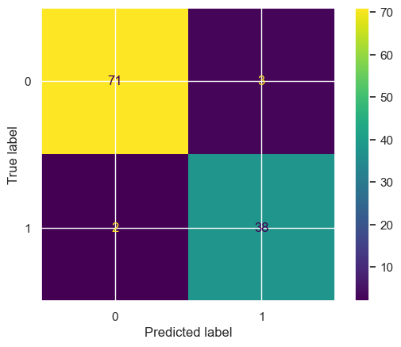

```python
ConfusionMatrixDisplay(confusion_matrix=confusion_matrix(y_test,log_model.predict(X_test))).plot()
```

```
<sklearn.metrics._plot.confusion_matrix.ConfusionMatrixDisplay at 0x211d9ee2340>
```

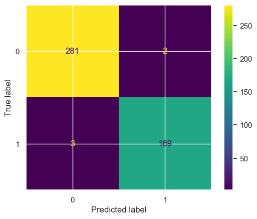

```python
ConfusionMatrixDisplay(confusion_matrix=confusion_matrix(y_train,log_model.predict(X_train))).plot()
```

## Logistic Regression Tuned model

```python
log_modelTN= LogisticRegression(penalty = 'l2' , solver = 'lbfgs' , C = 10 , tol = 0.2,max_iter = 500)
log_modelTN.fit(X_train,y_train)
```

```
LogisticRegression(C=10, max_iter=500, tol=0.2)
```

```python
print(classification_report(y_test,log_modelTN.predict(X_test)))
```

```
              precision    recall  f1-score   support

           0       0.96      0.97      0.97        74
           1       0.95      0.93      0.94        40

    accuracy                           0.96       114
   macro avg       0.95      0.95      0.95       114
weighted avg       0.96      0.96      0.96       114
```

```
<sklearn.metrics._plot.confusion_matrix.ConfusionMatrixDisplay at 0x211d904bf10>
```

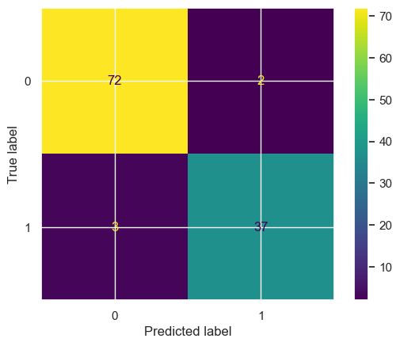

```python
ConfusionMatrixDisplay(confusion_matrix=confusion_matrix(y_test,log_modelTN.predict(X_test))).plot()
```

## Decision Tree Default Model

```python
from sklearn.tree import DecisionTreeClassifier
```

```python
dt1_model= DecisionTreeClassifier()
dt1_model.fit(X_train,y_train)
```

```
DecisionTreeClassifier()
```

```python
print(classification_report(y_test,dt1_model.predict(X_test)))
```

```
              precision    recall  f1-score   support

           0       0.99      0.89      0.94        74
           1       0.83      0.97      0.90        40

    accuracy                           0.92       114
   macro avg       0.91      0.93      0.92       114
weighted avg       0.93      0.92      0.92       114
```

```
<sklearn.metrics._plot.confusion_matrix.ConfusionMatrixDisplay at 0x211cb100610>
```

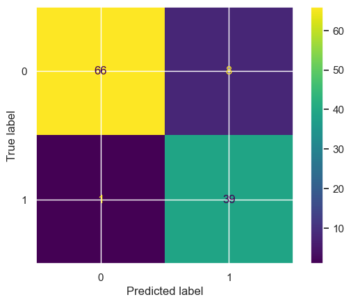

```python
ConfusionMatrixDisplay(confusion_matrix=confusion_matrix(y_test,dt1_model.predict(X_test))).plot()
```

## Desicion Tree Tuned Model

```python
from sklearn.model_selection import GridSearchCV, RandomizedSearchCV
```

```python
params={'max_depth':[3,5,7,10],
 'min_samples_leaf':[3,5,10,15],
 'ccp_alpha':[0,0.005,0.01]}
```

```python
dt2_model=DecisionTreeClassifier()
```

```python
dt2_model=GridSearchCV(dt2_model,params,cv=5,scoring='recall')
```

```python
dt2_model.fit(X_train,y_train)
```

```
GridSearchCV(cv=5, estimator=DecisionTreeClassifier(),
             param_grid={'ccp_alpha': [0, 0.005, 0.01],
                         'max_depth': [3, 5, 7, 10],
                         'min_samples_leaf': [3, 5, 10, 15]},
             scoring='recall')
```

```python
dt2_model.best_params_
```

```
{'ccp_alpha': 0, 'max_depth': 3, 'min_samples_leaf': 15}
```

```python
print(classification_report(y_test,dt2_model.predict(X_test)))
```

```
              precision    recall  f1-score   support

           0       0.99      0.93      0.96        74
           1       0.89      0.97      0.93        40

    accuracy                           0.95       114
   macro avg       0.94      0.95      0.94       114
weighted avg       0.95      0.95      0.95       114
```

## Random Forest Default Model

```python
from sklearn.ensemble import RandomForestClassifier
```

```python
rf1=RandomForestClassifier()
rf1.fit(X_train,y_train)
```

```
RandomForestClassifier()
```

```python
print(classification_report(y_test,rf1.predict(X_test)))
```

```
              precision    recall  f1-score   support

           0       0.99      0.93      0.96        74
           1       0.89      0.97      0.93        40

    accuracy                           0.95       114
   macro avg       0.94      0.95      0.94       114
weighted avg       0.95      0.95      0.95       114
```

```
<sklearn.metrics._plot.confusion_matrix.ConfusionMatrixDisplay at 0x211cb474760>
```

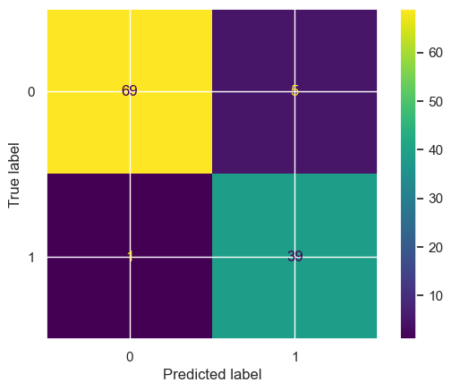

```python
ConfusionMatrixDisplay(confusion_matrix=confusion_matrix(y_test,rf1.predict(X_test))).plot()
```

## Random Forest Tuned Model

```python
params={'max_depth':[3,5,7,10],
 'min_samples_leaf':[3,5,10,15],
 'max_samples':[0.3,0.5,0.7,1.0],
 'n_estimators':[25,50,100,500]}
```

```python
rf2_model=RandomForestClassifier()
```

```python
rf2=RandomizedSearchCV(rf2_model, param_distributions=params, n_iter=100, cv=5, random_state=42)
```

```python
rf2.fit(X_train,y_train)
```

```
RandomizedSearchCV(cv=5, estimator=RandomForestClassifier(), n_iter=100,
                   param_distributions={'max_depth': [3, 5, 7, 10],
                                        'max_samples': [0.3, 0.5, 0.7, 1.0],
                                        'min_samples_leaf': [3, 5, 10, 15],
                                        'n_estimators': [25, 50, 100, 500]},
                   random_state=42)
```

```python
rf2.best_params_
```

```
{'n_estimators': 25, 'min_samples_leaf': 3, 'max_samples': 1.0, 'max_depth': 7}
```

```python
print(classification_report(y_test,rf2.predict(X_test)))
```

```
              precision    recall  f1-score   support

           0       0.99      0.95      0.97        74
           1       0.91      0.97      0.94        40

    accuracy                           0.96       114
   macro avg       0.95      0.96      0.95       114
weighted avg       0.96      0.96      0.96       114
```

```
<sklearn.metrics._plot.confusion_matrix.ConfusionMatrixDisplay at 0x211d8684430>
```

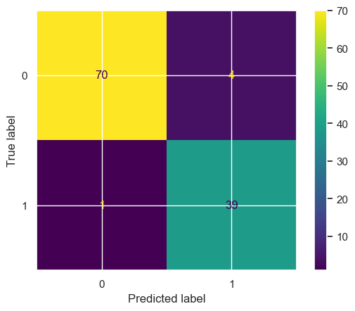

```python
ConfusionMatrixDisplay(confusion_matrix=confusion_matrix(y_test,rf2.predict(X_test))).plot()
```

## Multi-layer Perceptron classifier

```python
from sklearn.neural_network import MLPClassifier
mlp_model = MLPClassifier(activation = 'logistic' , hidden_layer_sizes = 5 , solver = 'lbfgs'  , alpha= 0.1,random_state = 44,max_iter = 1000)
mlp_model.fit(X_train,y_train)
```

```
MLPClassifier(activation='logistic', alpha=0.1, hidden_layer_sizes=5,
              max_iter=1000, random_state=44, solver='lbfgs')
```

```
<sklearn.metrics._plot.confusion_matrix.ConfusionMatrixDisplay at 0x211cb463d90>
```

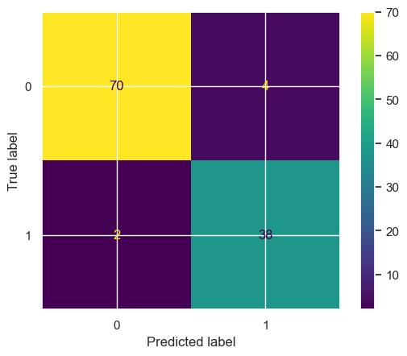

```python
ConfusionMatrixDisplay(confusion_matrix=confusion_matrix(y_test,mlp_model.predict(X_test))).plot()
```

```python
print(classification_report(y_test,mlp_model.predict(X_test)))
```

```
              precision    recall  f1-score   support

           0       0.97      0.95      0.96        74
           1       0.90      0.95      0.93        40

    accuracy                           0.95       114
   macro avg       0.94      0.95      0.94       114
weighted avg       0.95      0.95      0.95       114
```

# Оценка на представяне на моделите

```python
from sklearn.metrics import classification_report, confusion_matrix, ConfusionMatrixDisplay
```

```python
def model_report(model,model_id, positive, negative):
 """
 model - trained model
 clr - classification report as dict
 positive - positive class
 negative - negative class
 """

 clr=classification_report(y_test,model.predict(X_test),output_dict=True)
 data={'model':str(model),
 'sensitivity':clr[str(positive)]['recall'],
 'specificity':clr[str(negative)]['recall'],
 'f1 score':clr[str(positive)]['f1-score'],
 'accuracy':clr['accuracy'],
 'balanced accuracy':clr['macro avg']['recall'],
 'auc':roc_auc_score(y_test,model.predict_proba(X_test)[:,1])
 }
 return pd.DataFrame(data=data, index=[model_id])
```

### Дефинираме списък с обучените модели и потребителски етикети

```python
models=pd.DataFrame(data={'model':[log_model,log_modelTN,dt1_model,dt2_model,rf1,rf2,mlp_model],
 'model id':['Logistic Regression','Logistic Regression Tuned','DesTree default', 'DesTree Tuned','RandForest default','RandForest Tuned','Multi-layer']})
```

```python
report=pd.DataFrame()
for item in models.index:
 model=models['model'][item]
 model_id=models['model id'][item]
 report=pd.concat([report,model_report(model,model_id,1,0)])
report
```

|  | model | sensitivity | specificity | f1 score | accuracy | balanced accuracy | auc |
| --- | --- | --- | --- | --- | --- | --- | --- |
| Logistic Regression | LogisticRegression(max_iter=15000) | 0.950 | 0.959459 | 0.938272 | 0.956140 | 0.954730 | 0.993919 |
| Logistic Regression Tuned | LogisticRegression(C=10, max_iter=500, tol=0.2) | 0.925 | 0.972973 | 0.936709 | 0.956140 | 0.948986 | 0.992905 |
| DesTree default | DecisionTreeClassifier() | 0.975 | 0.891892 | 0.896552 | 0.921053 | 0.933446 | 0.933446 |
| DesTree Tuned | GridSearchCV(cv=5, estimator=DecisionTreeClass... | 0.975 | 0.932432 | 0.928571 | 0.947368 | 0.953716 | 0.981419 |
| RandForest default | RandomForestClassifier() | 0.975 | 0.932432 | 0.928571 | 0.947368 | 0.953716 | 0.989865 |
| RandForest Tuned | RandomizedSearchCV(cv=5, estimator=RandomFores... | 0.975 | 0.945946 | 0.939759 | 0.956140 | 0.960473 | 0.985135 |
| Multi-layer | MLPClassifier(activation='logistic', alpha=0.1... | 0.950 | 0.945946 | 0.926829 | 0.947368 | 0.947973 | 0.994932 |

## Сравняване на моделите

### Сравнение по AUC

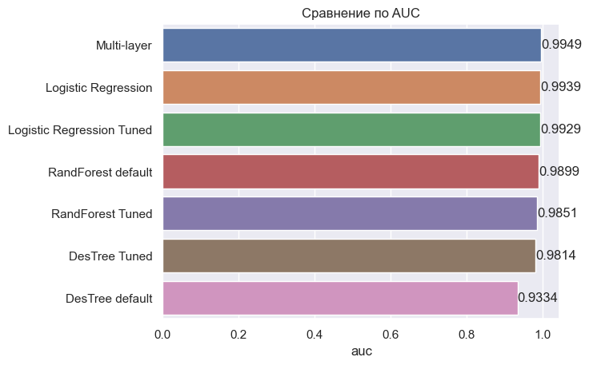

```python
g=sns.barplot(data=report.sort_values('auc',ascending=False),
 y=report.sort_values('auc',ascending=False).index,
 x='auc')
g.set(title='Сравнение по AUC')
for i in g.containers:
 g.bar_label(i,fmt='%.4f')
```

С най-висока **AUC** е моделът **Multi-layer classifier**

### Сравнение по balanced accuracy

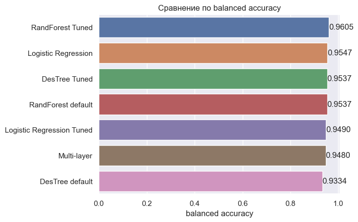

```python
g=sns.barplot(data=report.sort_values('balanced accuracy',ascending=False),
 y=report.sort_values('balanced accuracy',ascending=False).index,
 x='balanced accuracy')
g.set(title='Сравнение по balanced accuracy')
for i in g.containers:
 g.bar_label(i,fmt='%.4f')
```

С най-висока балансирана точност е моделът **Random Forest** с оптимални стойности на хипер-параметрите

### Сравнение по sensitivity

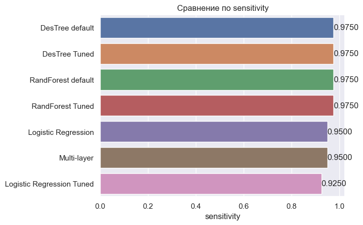

```python
g=sns.barplot(data=report.sort_values('sensitivity',ascending=False),
 y=report.sort_values('sensitivity',ascending=False).index,
 x='sensitivity')
g.set(title='Сравнение по sensitivity')
for i in g.containers:
 g.bar_label(i,fmt='%.4f')
```

### Сравнение по specicficity

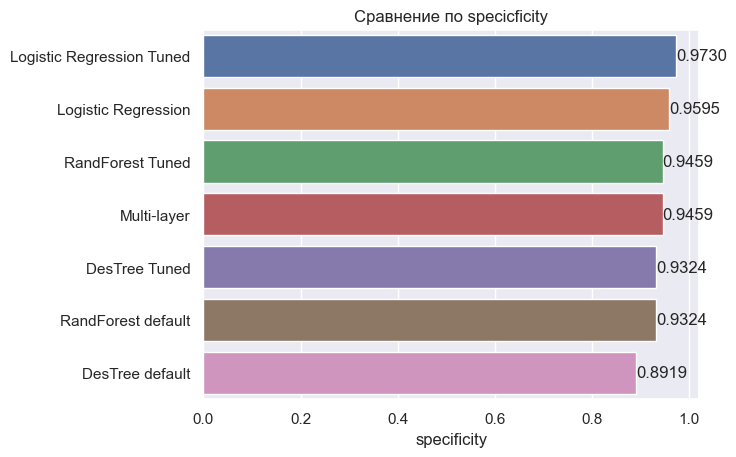

```python
g=sns.barplot(data=report.sort_values('specificity',ascending=False),
 y=report.sort_values('specificity',ascending=False).index,
 x='specificity')
g.set(title='Сравнение по specicficity')
for i in g.containers:
 g.bar_label(i,fmt='%.4f')
```

С най-висока специфичност е моделът **Logistic Regression** с оптимални стойности на хипер-параметрите

##### От направеното сравнение на различни метрики за представяне можем да заключим, че всички модели са в състояние да класифицират почти правилно рак.

# Интерпретиране на моделите

```python
import matplotlib.pyplot as plt
from sklearn.metrics import precision_recall_curve
```

#### Precision Recall Curve за Random Forest Tuned

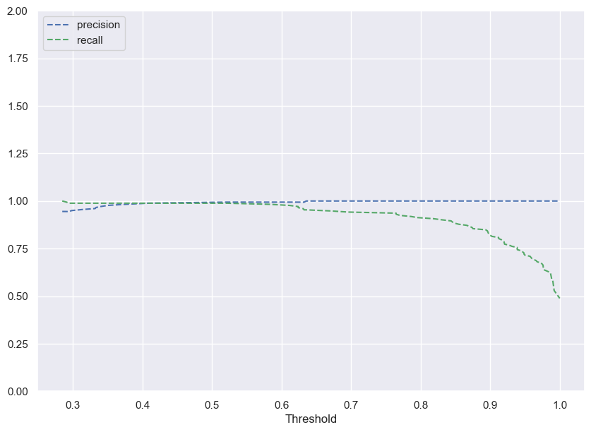

```python
y_scores_rf2 = rf2.predict_proba(X_train) # predict_proba дава вероятността всяко наблюдение да принадлежи към всеки клас


precisions_rf2, recalls_rf2, thresholds_rf2 = precision_recall_curve(y_train, y_scores_rf2[:, 1])

plt.figure(figsize = (10, 7))
plt.plot(thresholds_rf2, precisions_rf2[:-1], 'b--', label = 'precision')
plt.plot(thresholds_rf2, recalls_rf2[:-1], 'g--', label = 'recall')
plt.xlabel('Threshold')
plt.legend(loc = 'upper left')
plt.ylim([0, 2])
plt.show()
```

### Kоефициентите на логистична регресия

```python
cols = X.columns

coef_lg = log_model.coef_

pd.DataFrame(coef_lg,columns = cols).T.sort_values(by = 0, ascending = False)
```

|  | 0 |
| --- | --- |
| radius_se | 1.340124 |
| texture_worst | 1.137869 |
| concavity_worst | 1.108140 |
| symmetry_worst | 1.003142 |
| radius_worst | 0.964078 |
| smoothness_worst | 0.934225 |
| area_worst | 0.932840 |
| area_se | 0.913112 |
| concavity_mean | 0.799974 |
| perimeter_se | 0.789979 |
| perimeter_worst | 0.785269 |
| concave points_mean | 0.761733 |
| concave points_worst | 0.649196 |
| area_mean | 0.626146 |
| radius_mean | 0.548275 |
| perimeter_mean | 0.519409 |
| fractal_dimension_worst | 0.328634 |
| texture_mean | 0.301035 |
| concave points_se | 0.236336 |
| texture_se | 0.178605 |
| id | 0.163390 |
| smoothness_se | 0.122524 |
| smoothness_mean | 0.037711 |
| compactness_worst | -0.013307 |
| symmetry_mean | -0.046640 |
| concavity_se | -0.196612 |
| symmetry_se | -0.278860 |
| fractal_dimension_mean | -0.386499 |
| fractal_dimension_se | -0.448023 |
| compactness_mean | -0.586531 |
| compactness_se | -0.707766 |

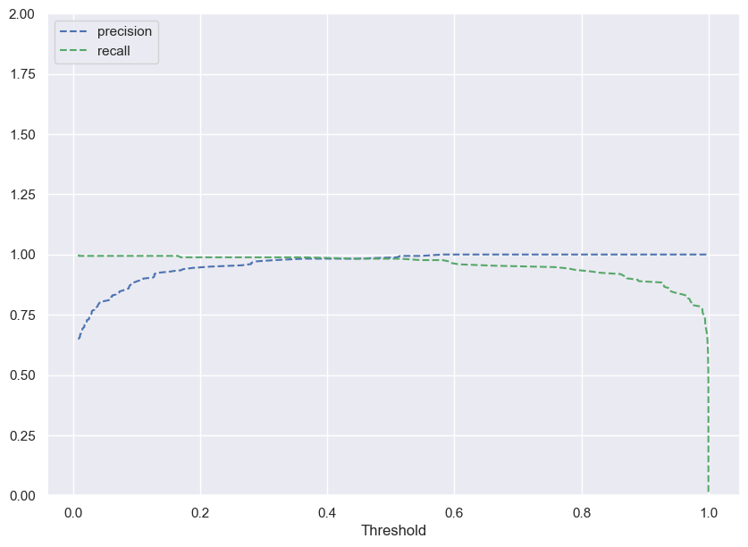

```python
y_scores_lg = log_model.predict_proba(X_train) # predict_proba дава вероятността всяко наблюдение да принадлежи към всеки клас

precisions_lg, recalls_lg, thresholds_lg = precision_recall_curve(y_train, y_scores_lg[:, 1])

plt.figure(figsize = (10, 7))
plt.plot(thresholds_lg, precisions_lg[:-1], 'b--', label = 'precision')
plt.plot(thresholds_lg, recalls_lg[:-1], 'g--', label = 'recall')
plt.xlabel('Threshold')
plt.legend(loc = 'upper left')
plt.ylim([0, 2])
plt.show()
```

### Избираме модела с оптимизирани стойности на параметрите

```python
best=rf2.best_estimator_
```

### Изчисляваме относителна значимост на факторните променливи

```python
X_test_col = pd.DataFrame(X_test, columns=X.columns)
features = pd.DataFrame(data={'feature': list(X.columns), 'importance': list(best.feature_importances_)})
features.sort_values('importance', ascending=False, inplace=True)
features
```

|  | feature | importance |
| --- | --- | --- |
| 28 | concave points_worst | 0.162897 |
| 1 | radius_mean | 0.108786 |
| 23 | perimeter_worst | 0.102392 |
| 7 | concavity_mean | 0.086948 |
| 24 | area_worst | 0.086394 |
| 3 | perimeter_mean | 0.081142 |
| 8 | concave points_mean | 0.072619 |
| 14 | area_se | 0.068607 |
| 4 | area_mean | 0.055321 |
| 26 | compactness_worst | 0.031842 |
| 21 | radius_worst | 0.025031 |
| 27 | concavity_worst | 0.022937 |
| 22 | texture_worst | 0.022023 |
| 13 | perimeter_se | 0.017976 |
| 2 | texture_mean | 0.009307 |
| 30 | fractal_dimension_worst | 0.006626 |
| 11 | radius_se | 0.005069 |
| 25 | smoothness_worst | 0.004721 |
| 5 | smoothness_mean | 0.004307 |
| 10 | fractal_dimension_mean | 0.003314 |
| 29 | symmetry_worst | 0.003253 |
| 9 | symmetry_mean | 0.002975 |
| 17 | concavity_se | 0.002901 |
| 18 | concave points_se | 0.002875 |
| 15 | smoothness_se | 0.002557 |
| 16 | compactness_se | 0.002326 |
| 0 | id | 0.001411 |
| 19 | symmetry_se | 0.001374 |
| 20 | fractal_dimension_se | 0.000940 |
| 12 | texture_se | 0.000734 |
| 6 | compactness_mean | 0.000396 |

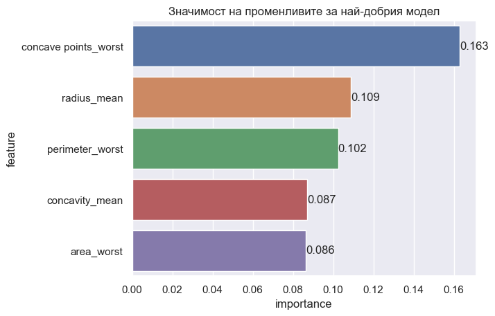

```python
g=sns.barplot(x='importance',y='feature',data=features[:5])
for i in g.containers:
 g.bar_label(i,fmt='%.3f')
g.set_title('Значимост на променливите за най-добрия модел')
plt.show()
```

Според анализа на относителната значимост на факторните променливи в база данни, можем да заключим, че тези 5 фактора са с най - голяма значимост за класификацията.

## SHAP summary plot

```python
import shap
shap.initjs()
```

```
No data for colormapping provided via 'c'. Parameters 'vmin', 'vmax' will be ignored
```

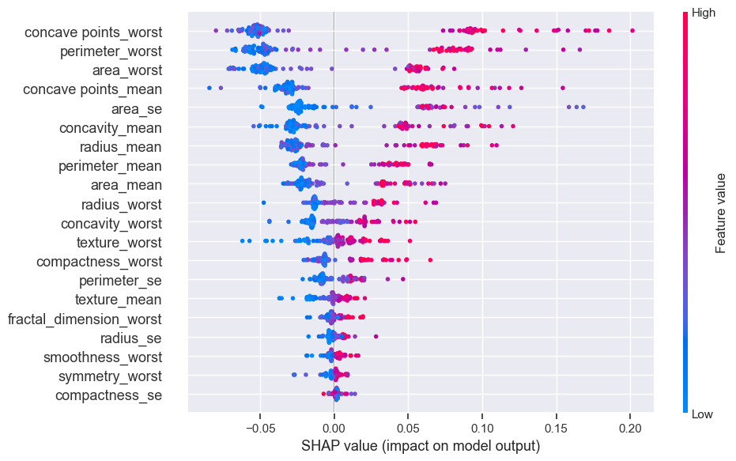

```python
explainer = shap.TreeExplainer(best)
shap_obj = explainer(X_test)
shap_values = explainer.shap_values(X_test)
shap.summary_plot(shap_values=np.take(shap_obj.values, 1, axis=-1),
                   features=pd.DataFrame(X_test, columns=X.columns),
                   feature_names=list(X.columns),
                   plot_size=(10, 6))
```